# Main_analysis_original

Kevin Healy

2024-08-13

#Varroa Analysis

This document outlines the code used for the analysis in O Connell et al 2024 regarding the effects of various treatments on Varroa based on a literature search (see main manuscript for details). The analysis measures the effect of various treatments using the log ratio between the treatment and its associated control. This approach allows us to compared values from various sources and treatments from a wide general perspective.

##Load up Packages

We will use the MCMCglmm package which allows us to run mixed effects models in a Bayesian framework.

```r
library(MCMCglmm)
library(hdrcde)
```

##Data The raw data set Varroa_treatment_database_2023.10.27.csv can be found in the supplementary of the manuscript. Once loaded we will also create a new variable which further splits the category Chemical into “Synthetic” and “Agriculturally_Organic”.

```r
varroa_data <- read.csv("Varroa_treatment_database_2023.10.27.csv",
                        sep = ",",
                        header = T)


#we will add a breakdown of synthetic versus non synthetic
chem_split <- as.vector(varroa_data$categoryTreatment)


#We will loop around and replace the the term Chemical with its entry in the
#SubCategory1Treatment variable
for(i in 1:length(chem_split)){

  if(chem_split[i] == "Chemical")
  {chem_split[i] <- varroa_data$SubCategory1Treatment[i]}

  }


#Set it so Synthetic chemicals are the baseline.
chem_split <- factor(chem_split, levels = c("Synthetic",
                                            "Agriculturally_Organic",
                                            "Biological",
                                            "Physical",
                                            "Mixed"))
#Add this new chem_split variable to the data set.
varroa_data <-  data.frame(varroa_data,
                                    chem_split)
```

#log ratio calculations To calculate the log ratio vales we use a loop so that for every study we calculate the pairwise log ratio between the studies control and each of the treatment measures as log(treatment/control).

There are four different broad measurement types in the analysis.

1. HoneyBeeIncrease: Those that measure aspects of honey bees where an increase in the measure is a measure of the positive effects of the treatment. For example, if the number of bees increases in response to some treatment.
2. HoneyBeeReduction Those that measure aspects of honey bees where a increase in the measure is a measure of the negative effects of the treatment. For example, if the mortality rate of bees increases in response to some treatment.
3. VarroaReduction: Those that measure aspects of Varroa where an increase in the measure is a measure of the positive effects of the treatment. For example, if the Varroa mortality rate increases in response to some treatment.
4. VarroaIncrease: Those that measure aspects of Varroa where an increase in the measure is a measure of the negative effects of the treatment. For example, if the Varroa population size increases in response to some treatment.

In order to include all 4 of these groups together in the main analysis we reversed the sign for the log ratio of HoneyBeeReduction and VarroaIncrease values so that positive values indicate positive outcomes for bee control.

We do not include any infinite ratios caused by either log(1/0) or log(0/1). We change log(0/0) values to zero as while it gives an NA a zero value of no change is comparable to values such as log(1/1). First we will create a loop for each of the Response Variable Category types (HoneyBeeIncrease, Honey- BeeReduction, VarroaIncrease, VarroaReduction)

##HoneyBeeIncrease Loop matching up all the treatments and controls for measures where an increase is a positive outcome for bees. This loop only compares treatment values within studies and for the same response target (for example, within studies there may be several response targets such as adults, juveniles etc). 1 infinite value was removed.

```r
#subset to just responses with HoneyBeeIncrease
HoneyBeeIncrease_data <- varroa_data[varroa_data$ResponseVariableCategory ==
                                       "HoneyBeeIncrease",]


#create a column that has unique treatment and response numbers
HoneyBeeIncrease_data$tre_resp <-  paste(HoneyBeeIncrease_data$Treatment_Group,
                                         "_",
                                         HoneyBeeIncrease_data$ResponseNo.,
                                         sep = "")


#empty list to put the final paired rows into
HoneyBeeIncrease_tret_group_temp <- list()

#Data for every study
for (i in 1:length(unique(HoneyBeeIncrease_data$StudyID))){
  hbi_stud <- HoneyBeeIncrease_data[HoneyBeeIncrease_data$StudyID ==
                                      unique(HoneyBeeIncrease_data$StudyID)[i],]

  #Data for every response target (juvinal. adult etc)
  for(z in 1:length(unique(hbi_stud$ResponseVariableTarget))){
    hbi_stud_res <- hbi_stud[hbi_stud$ResponseVariableTarget ==
                               unique(hbi_stud$ResponseVariableTarget)[z],]

    for(w in 1:length(unique(hbi_stud_res$tre_resp))){
        hbi_tret <- hbi_stud_res[hbi_stud_res$tre_resp ==
                                   unique(hbi_stud_res$tre_resp)[w],]

#HoneyBeeIncrease_tret_group_temp <- vector()
      for(t in 1:length(hbi_tret[hbi_tret$Status != "control",1])){

#we default to the first control for now.
hbi_control <- hbi_tret[hbi_tret$Status == "control", ][1,]

#rename the colunm names to _control
colnames(hbi_control) <- paste(names(hbi_control),"_control",sep = "")

#we default to the first control for now.
HoneyBeeIncrease_tret_group_temp[[length(HoneyBeeIncrease_tret_group_temp)+1]]<-
  cbind(hbi_tret[hbi_tret$Status != "control",][t,],
        hbi_control)

        } }

  } }

#Now we just
HoneyBeeIncrease_paired <- do.call(rbind.data.frame,
                                   HoneyBeeIncrease_tret_group_temp)


#We can add a row of the log ratio of the response mean value
#(specificResponseMean) divided by the control (specificResponseMean_control)
HoneyBeeIncrease_paired$logratio <-
  log(HoneyBeeIncrease_paired$specificResponseMean/
        HoneyBeeIncrease_paired$specificResponseMean_control)
```

```r
#lets recode the NaNs to 0 as they are caused by log(0/0)
#which for our purposes are the same as log(1/1)
HoneyBeeIncrease_paired[ is.nan(HoneyBeeIncrease_paired$logratio),
                         "logratio"] <- 0

#lets remove any pairs that are infinite.
#These are caused by zeros log(1/0) or log(0/1)
HoneyBeeIncrease_paired_fin <-
  HoneyBeeIncrease_paired[!(is.infinite(HoneyBeeIncrease_paired$logratio)),]

#Lets just set Chemical as the baseline
HoneyBeeIncrease_paired_fin$categoryTreatment <-
  factor(HoneyBeeIncrease_paired_fin$categoryTreatment,
                                                        levels = c("Chemical",
                                                                   "Physical",
                                                                   "Biological",
                                                                   "Mixed")
        )

#create a variable that gives a unique identify for nested country continent
HoneyBeeIncrease_paired_fin$Cont_Country <-
  paste0(HoneyBeeIncrease_paired_fin$Continent,
          HoneyBeeIncrease_paired_fin$Country)
```

##HoneyBeeReduction Loop matching up all the treatments and controls for measures where a decrease is a positive outcome for bees. This loop only compares treatment values within studies and for the same response target (for example, within studies there may be several response targets such as adults, juveniles etc). 59 infinite values were removed.

```r
#subset to just responses with HoneyBeeIncrease
HoneyBeeReduction_data <- varroa_data[varroa_data$ResponseVariableCategory ==
                                       "HoneyBeeReduction",]
#create a column that has unique treatment and response numbers
HoneyBeeReduction_data$tre_resp <-  paste(HoneyBeeReduction_data$Treatment_Group,
                                         "_",
                                         HoneyBeeReduction_data$ResponseNo.,
                                         sep = "")

#empty list to put the final paired rows into
HoneyBeeReduction_tret_group_temp <- list()

#Data for every study
  for (i in 1:length(unique(HoneyBeeReduction_data$StudyID))){
      hbr_stud <- HoneyBeeReduction_data[HoneyBeeReduction_data$StudyID ==
                                      unique(HoneyBeeReduction_data$StudyID)[i],]


#Data for every response target (juvinal. adult etc)
      for(z in 1:length(unique(hbr_stud$ResponseVariableTarget))){

      hbr_stud_res <- hbr_stud[hbr_stud$ResponseVariableTarget ==
                                 unique(hbr_stud$ResponseVariableTarget)[z],]

        for(w in 1:length(unique(hbr_stud_res$tre_resp))){

  hbr_tret <- hbr_stud_res[hbr_stud_res$tre_resp==unique(hbr_stud_res$tre_resp)[w],]

          for(t in 1:length(hbr_tret[hbr_tret$Status != "control",1])){

#we default to the first control for now.
hbr_control <- hbr_tret[hbr_tret$Status == "control", ][1,]

#rename the colunm names to _control
colnames(hbr_control) <- paste(names(hbr_control),"_control",sep = "")


#we default to the first control for now.
HoneyBeeReduction_tret_group_temp[[length(HoneyBeeReduction_tret_group_temp)+1]]<-
  cbind(hbr_tret[hbr_tret$Status != "control",][t,],
        hbr_control)
} }
} }


#Now we just
HoneyBeeReduction_paired <- do.call(rbind.data.frame,
                                    HoneyBeeReduction_tret_group_temp)
#We can add a row of the log ratio of the response mean value
#(specificResponseMean) divided by the control (specificResponseMean_control)
HoneyBeeReduction_paired$logratio <-
  log(HoneyBeeReduction_paired$specificResponseMean/
        HoneyBeeReduction_paired$specificResponseMean_control)
```

```r
#lets recode the NaNs to 0 as they are caused by log(0/0)
#which for our purposes are the same as log(1/1)
HoneyBeeReduction_paired[ is.nan(HoneyBeeReduction_paired$logratio),
                          "logratio"] <- 0


#lets remove any pairs that are infinite. #These are caused by zeros log(1/0) or log(0/1)
HoneyBeeReduction_paired_fin <-
  HoneyBeeReduction_paired[!(is.infinite(HoneyBeeReduction_paired$logratio)),]

#Lets just set Chemical as the baseline
HoneyBeeReduction_paired_fin$categoryTreatment <-
  factor(HoneyBeeReduction_paired_fin$categoryTreatment,
                                                        levels = c("Chemical",
                                                                   "Physical",
                                                                   "Biological",
                                                                   "Mixed")
  )

#create a variable that gives a unique identify for nested country continent
HoneyBeeReduction_paired_fin$Cont_Country <-
  paste0(HoneyBeeReduction_paired_fin$Continent,
         HoneyBeeReduction_paired_fin$Country)


#We can also create a version of the data set
#with the log ratio value flipped so that it can be read as a positive value

HoneyBeeReduction_paired_red_fin <- HoneyBeeReduction_paired_fin

HoneyBeeReduction_paired_red_fin$logratio <-
  -HoneyBeeReduction_paired_red_fin$logratio
```

VarroaIncrease Loop matching up all the treatments and controls for measures where a decrease is a positive outcome for bees. This loop only compares treatment values within studies and for the same response target (for example, within studies there may be several response targets such as adults, juveniles etc). 29 infinite values were removed.

```r
#subset to just responses with VarroaIncrease
VarroaIncrease_data <- varroa_data[varroa_data$ResponseVariableCategory ==
                                       "VarroaIncrease",]


#create a column that has unique treatment and response numbers
VarroaIncrease_data$tre_resp <-  paste(VarroaIncrease_data$Treatment_Group,
                                         "_",
                                         VarroaIncrease_data$ResponseNo.,
                                         sep = "")


#empty list to put the final paired rows into
VarroaIncrease_tret_group_temp <- list()


#Data for every study
for (i in 1:length(unique(VarroaIncrease_data$StudyID))){
  vi_stud <- VarroaIncrease_data[VarroaIncrease_data$StudyID ==
                                      unique(VarroaIncrease_data$StudyID)[i],]
  #Data for every response target (juvinal. adult etc)
  for(z in 1:length(unique(vi_stud$ResponseVariableTarget))){
    vi_stud_res <- vi_stud[vi_stud$ResponseVariableTarget ==
unique(vi_stud$ResponseVariableTarget)[z],]

    for(w in 1:length(unique(vi_stud_res$tre_resp))){
vi_tret <- vi_stud_res[vi_stud_res$tre_resp == unique(vi_stud_res$tre_resp)[w],]

      for(t in 1:length(vi_tret[vi_tret$Status != "control",1])){

#we default to the first control for now.
vi_control <- vi_tret[vi_tret$Status == "control", ][1,]

#rename the colunm names to _control
colnames(vi_control) <- paste(names(vi_control),"_control",sep = "")

#we default to the first control for now.
VarroaIncrease_tret_group_temp[[length(VarroaIncrease_tret_group_temp) + 1]]  <-
  cbind(vi_tret[vi_tret$Status != "control",][t,],
        vi_control)

      } }
  } }


#Now we just

VarroaIncrease_paired <- do.call(rbind.data.frame, VarroaIncrease_tret_group_temp)

#We can add a row of the log ratio of the response mean value
#(specificResponseMean) divided by the control (specificResponseMean_control)


VarroaIncrease_paired$logratio <-
  log(VarroaIncrease_paired$specificResponseMean/
        VarroaIncrease_paired$specificResponseMean_control)


#lets recode the NaNs to 0 as they are caused by log(0/0)
#which for our purposes are the same as log(1/1)
VarroaIncrease_paired[ is.nan(VarroaIncrease_paired$logratio), "logratio"] <- 0


#lets remove any pairs that are infinite.
#These are caused by zeros log(1/0) or log(0/1)
VarroaIncrease_paired_fin <-
  VarroaIncrease_paired[!(is.infinite(VarroaIncrease_paired$logratio)),]


#Lets just set Chemical as the baseline
VarroaIncrease_paired_fin$categoryTreatment <-
  factor(VarroaIncrease_paired_fin$categoryTreatment,levels = c("Chemical",
                                                                "Physical",
                                                                "Biological",
                                                                "Mixed")
  )


#create a variable that gives a unique identify for nested country continent
VarroaIncrease_paired_fin$Cont_Country <-
  paste0(VarroaIncrease_paired_fin$Continent,
         VarroaIncrease_paired_fin$Country)



#We can also create a version of the dataset
#with the log ratio value flipped so that it can be read as a positive value
VarroaIncrease_paired_red_fin <- VarroaIncrease_paired_fin
VarroaIncrease_paired_red_fin$logratio <- -VarroaIncrease_paired_red_fin$logratio
```

#VarroaReduction Loop matching up all the treatments and controls for measures where an increase is a positive outcome for bees. This loop only compares treatment values within studies and for the same response target (for example, within studies there may be several response targets such as adults, juveniles etc). 300 infinite values were removed.

```r
#subset to just responses with VarroaReduction
VarroaReduction_data <- varroa_data[varroa_data$ResponseVariableCategory ==
                                      "VarroaReduction",]

#create a column that has unique treatment and response numbers
VarroaReduction_data$tre_resp <-  paste(VarroaReduction_data$Treatment_Group,
                                         "_",
                                         VarroaReduction_data$ResponseNo.,
                                         sep = "")

#empty list to put the final paired rows into
VarroaReduction_tret_group_temp <- list()

#Data for every study
for (i in 1:length(unique(VarroaReduction_data$StudyID))){
  vr_stud <- VarroaReduction_data[VarroaReduction_data$StudyID ==
                                      unique(VarroaReduction_data$StudyID)[i],]

  #Data for every response target (juvinal. adult etc)
  for(z in 1:length(unique(vr_stud$ResponseVariableTarget))){
    vr_stud_res <- vr_stud[vr_stud$ResponseVariableTarget ==
                               unique(vr_stud$ResponseVariableTarget)[z],]

    for(w in 1:length(unique(vr_stud_res$tre_resp))){

vr_tret <- vr_stud_res[vr_stud_res$tre_resp == unique(vr_stud_res$tre_resp)[w],]

#HoneyBeeIncrease_tret_group_temp <- vector()
      for(t in 1:length(vr_tret[vr_tret$Status != "control",1])){

#we default to the first control for now.
vr_control <- vr_tret[vr_tret$Status == "control", ][1,]

#rename the colunm names to _control
colnames(vr_control) <- paste(names(vr_control),"_control",sep = "")

#we default to the first control for now.
VarroaReduction_tret_group_temp[[length(VarroaReduction_tret_group_temp) + 1]]<-
  cbind(vr_tret[vr_tret$Status != "control",][t,],
        vr_control)

      } }
  } }

#Now we just
VarroaReduction_paired <- do.call(rbind.data.frame,
                                  VarroaReduction_tret_group_temp)
#We can add a row of the log ratio of the response mean value
#(specificResponseMean) divided by the control (specificResponseMean_control)
VarroaReduction_paired$logratio <-
  log(c(VarroaReduction_paired$specificResponseMean)/
        c(VarroaReduction_paired$specificResponseMean_control))
```

```r
#lets recode the NaNs to 0 as they are caused by log(0/0)
#which for our purposes are the same as log(1/1)
VarroaReduction_paired[ is.nan(VarroaReduction_paired$logratio), "logratio"]<- 0

#lets remove any pairs that are infinite.
#These are caused by zeros log(1/0) or log(0/1)
VarroaReduction_paired_fin <-
  VarroaReduction_paired[!(is.infinite(VarroaReduction_paired$logratio)),]


#Lets just set Chemical as the baseline
VarroaReduction_paired_fin$categoryTreatment <-
  factor(VarroaReduction_paired_fin$categoryTreatment,
         levels = c("Chemical",
                    "Physical",
                    "Biological",
                    "Mixed"
                    )
         )

#create a variable that gives a unique identify for nested country continent
VarroaReduction_paired_fin$Cont_Country <-
  paste0(VarroaReduction_paired_fin$Continent,
         VarroaReduction_paired_fin$Country)
```

We can join all the studies together with the sign reversed so that a positive difference indicates postie outcomes for control.

We can combine the bee breeds into categories of C lineage (lugistica, carnica, lugistica/carnica hybrid, siciliana), A lineage (intermissa) O lineage (caucasia, anatolica, meda, syriaca), Africanised and Buckfast bees.

```r
#This just puts all the datasets together.

#We need to rename the median response column to match

names(HoneyBeeIncrease_paired_fin)[names(HoneyBeeIncrease_paired_fin) == "median_hbi_tret_res"] <- "median_res"
names(HoneyBeeReduction_paired_red_fin)[names(HoneyBeeReduction_paired_red_fin) == "median_hbr_tret_res"] <- "median_res"
names(VarroaIncrease_paired_red_fin)[names(VarroaIncrease_paired_red_fin) == "median_vi_tret_res"] <- "median_res"
names(VarroaReduction_paired_fin)[names(VarroaReduction_paired_fin) == "median_vr_tret_res"] <- "median_res"


#Notice HoneyBeeReduction_paired_red_fin and VarroaIncrease_paired_red_fin
#have their signs reversed
Full_comb_data <- rbind(HoneyBeeIncrease_paired_fin,
                             HoneyBeeReduction_paired_red_fin,
                             VarroaIncrease_paired_red_fin,
                             VarroaReduction_paired_fin)


################ Create bee breed catagories ###############
##############################################

#fix typo
Full_comb_data[Full_comb_data$Genetic_group_bees == "Apis_mellifer_carnica",
                  "Genetic_group_bees"] <- "Apis_mellifera_carnica"

Full_comb_data$Lineage <- Full_comb_data$Genetic_group_bees

#Set out C lineage
Full_comb_data[Full_comb_data$Lineage %in% c("Apis_mellifera_carnica",
"Apis_mellifera_ligustica_Apis_mellifera_carnica_natural_hybrids",
"Apis_mellifera_carnica_Apis_mellifera_ligustica_mixture",
"Apis_mellifera_siciliana",
"Apis_mellifera_ligustica"),
                              "Lineage"] <- "C_lineage"

#Set out A lineage
Full_comb_data[Full_comb_data$Lineage %in% c("Apis_mellifera_intermissa"),
                              "Lineage"] <- "A_lineage"

#Set out O lineage
Full_comb_data[Full_comb_data$Lineage %in% c("Apis_mellifera_anatolica",
                                                 "Apis_mellifera_meda",
                                             "Apis_mellifera_caucasica",
                                             "Apis_mellifera_syriaca"),
                              "Lineage"] <- "O_lineage"
#Set out Af lineage
Full_comb_data[Full_comb_data$Lineage %in% c("Apis_mellifera_africanised"),
                              "Lineage"] <- "Af_lineage"

#Set out buckfast lineage
Full_comb_data[Full_comb_data$Lineage %in% c("Apis_mellifera_buckfast"),
                              "Lineage"] <- "Buck_lineage"


################ Split the data ###############
##############################################
#just bee data
Full_bees_data <- rbind(HoneyBeeIncrease_paired_fin,
                             HoneyBeeReduction_paired_red_fin)

#Reset the levels for bees so workers are the baseline
Full_bees_data$ResponseVariableTarget <-
  factor(Full_bees_data$ResponseVariableTarget,
                                                levels = c("Honey_bee_worker",
                                                           "Honey_bee_colony",
                                                           "Honey_bee_juvenile",
                                                           "Honey_bee_product",
                                                           "Honey_bee_queen"))

#just vorroa data
Full_varroa_data <- rbind(VarroaIncrease_paired_red_fin,
                             VarroaReduction_paired_fin)
```

##MCMCglmm analysis #Prior and parameters Now that we have a set of log ratios we can run some analysis. We first set up a non-informative prior for our our models, with a flat gamma distribution used as the non-informative prior for each for the random terms. For more info on priors see the Course notes (http://cran.nexr.com/web/packages/MCMCglmm/ vignettes/CourseNotes.pdf).

```r
prior_d <-list(R = list(V = 1, nu=0.002),
            G = list(G1=list(V = 1, nu=0.002, alpha.mu= 0, alpha.V= 10^3),
                     G2=list(V = 1, nu=0.002, alpha.mu= 0, alpha.V= 10^3),
                     G3=list(V = 1, nu=0.002, alpha.mu= 0, alpha.V= 10^3)
))
```

We will also set the number of iterations (nitt), the burnin (burnin) and the thining (thining).

```r
burnin <- c(10000)
nitt <- c(110000)
thining <- c(50)
```

#Main model The first model will include all studies with a positive values associated with a positive outcome for bee health. We run three chains (mod_full, mod_full2 and mod_full3) so we can test if they converge.

```r
mod_full <- MCMCglmm(logratio ~ chem_split
                                + Context,
                                 rcov=~units,
                                 random =~StudyID_control
                                          + Continent
                                          + Cont_Country,
                                 family ="gaussian",
                                 data = Full_comb_data,
                                 nitt = nitt,
                                 thin = thining,
                                 burnin = burnin,
                                 prior = prior_d,
                                 verbose = F )

#second model acts as second chain for convergence
mod_full2 <- MCMCglmm(logratio ~ chem_split
                                  + Context,
                                 rcov=~units,
                                 random =~StudyID_control
                                          + Continent
                                          + Cont_Country,
                                 family ="gaussian",
                                 data = Full_comb_data,
                                 nitt = nitt,
                                 thin = thining,
                                 burnin = burnin,
                                 prior = prior_d,
                                 verbose = F )

#second model acts as second chain for convergence #Add a 3rd later for final check
mod_full3 <- MCMCglmm(logratio ~ chem_split
                                  + Context,
                                 rcov=~units,
                                 random =~StudyID_control
                                          + Continent
                                          + Cont_Country,
                                 family ="gaussian",
                                 data = Full_comb_data,
                                 nitt = nitt,
                                 thin = thining,
                                 burnin = burnin,
                                 prior = prior_d,
                                 verbose = F )

summary(mod_full)
```

```
##
##  Iterations = 10001:109951
##  Thinning interval  = 50
##  Sample size  = 2000
##
##  DIC: 5979.756
##
##  G-structure:  ~StudyID_control
##
##                 post.mean l-95% CI u-95% CI eff.samp
## StudyID_control    0.7355   0.5327   0.9617     2000
##
##                ~Continent
##
##           post.mean  l-95% CI u-95% CI eff.samp
## Continent    0.1389 1.957e-10   0.5745     1496
##
##                ~Cont_Country
##
##              post.mean  l-95% CI u-95% CI eff.samp
## Cont_Country   0.08533 7.928e-07   0.2837     1169
##
##  R-structure:  ~units
##
##       post.mean l-95% CI u-95% CI eff.samp
## units     0.977   0.9175    1.041     2000
##
##  Location effects: logratio ~ chem_split + Context
##
##                                  post.mean l-95% CI u-95% CI eff.samp  pMCMC
## (Intercept)                        0.97640  0.59304  1.41748     2000  0.003
## chem_splitAgriculturally_Organic  -0.13363 -0.30911  0.03404     2000  0.120
## chem_splitBiological              -0.71475 -1.05799 -0.36262     2000 <5e-04
## chem_splitPhysical                -0.58805 -1.29509  0.17154     2000  0.132
## chem_splitMixed                   -0.58190 -1.57029  0.38727     1856  0.265
## ContextLab                         0.19929 -0.05214  0.45667     2000  0.140
##
## (Intercept)                      **
## chem_splitAgriculturally_Organic
## chem_splitBiological             ***
## chem_splitPhysical
## chem_splitMixed
## ContextLab
## ---
## Signif. codes:  0 '***' 0.001 '**' 0.01 '*' 0.05 '.' 0.1 ' ' 1
```

Overall Synthetic chemicals have a significant overall positive outcome at a ratio of 2.7/1 when compared to the treatment compared to control. This is significantly higher when compared to biological controls which only have a positive outcome effect at a ratio of 1.3/1 when compared to the control.

Both Physical and Mixed treatments are found to have reduced effects on outcomes when compared to synthetic chemicals, however neither are significantly different. Finally, there is weak support that treatments have higher positive outcomes when tested in lab based setting, however, this is also not significant.

We can do a simple plot of our results.

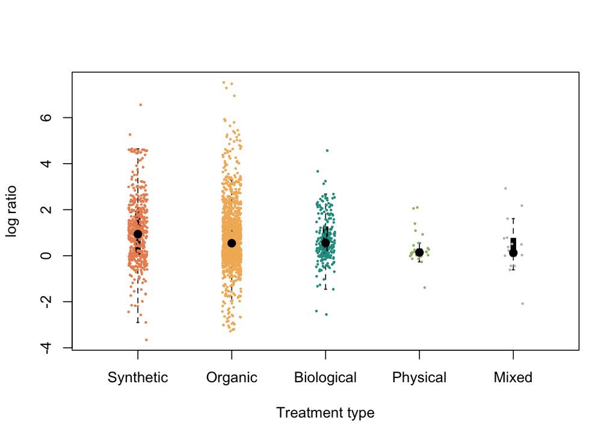

```r
plot(Full_comb_data$logratio ~ Full_comb_data$chem_split,
     col ="black",
     bty = "n",
     boxwex = 0.05,
     ylab = "log ratio",
     xlab = "Treatment type",
     pch = 16,
     cex = 0,
     names = c("Synthetic", "Organic", "Biological", "Physical", "Mixed"))

#We can plot the points for Synthetic
points(Full_comb_data[Full_comb_data$chem_split == "Synthetic", "logratio"] ~ jitter(as.integer(Full_comb_data[Full_comb_data$chem_split == "Synthetic",                                           "chem_split"]),
                  amount = 0.1),
       pch = 16,
       col = rgb(236, 143, 94, max=255),
       cex = 0.4)

points(median(Full_comb_data[Full_comb_data$chem_split == "Synthetic", "logratio"])
       ~ c(1),
       pch = 16,
       col = "black",
       cex = 1.3)


#We can plot the points for Agriculturally_Organic
points(Full_comb_data[Full_comb_data$chem_split == "Agriculturally_Organic",
                      "logratio"] ~
         jitter(as.integer(Full_comb_data[Full_comb_data$chem_split ==
                                            "Agriculturally_Organic",                                           "chem_split"]),
       amount = 0.1),
       pch = 16,
       col = rgb(243, 182, 100, max=255),
       cex = 0.4)

points(median(Full_comb_data[Full_comb_data$chem_split == "Agriculturally_Organic",
                             "logratio"]) ~ c(2),
       pch = 16,
       col = "black",
       cex = 1.3)

#We can plot the points for Biological
points(Full_comb_data[Full_comb_data$chem_split == "Biological", "logratio"] ~ jitter(as.integer(Full_comb_data[Full_comb_data$chem_split == "Biological",                                           "chem_split"]),
                  amount = 0.1),
       pch = 16,
       col = rgb(33, 156, 144, max=255),
       cex = 0.4)

points(median(Full_comb_data[Full_comb_data$chem_split == "Biological", "logratio"])
       ~ c(3),
       pch = 16,
       col = "black",
       cex = 1.3)



#We can plot the points for Physical
points(Full_comb_data[Full_comb_data$chem_split == "Physical", "logratio"] ~ jitter(as.integer(Full_comb_data[Full_comb_data$chem_split == "Physical",                                           "chem_split"]),
                  amount = 0.1),
       pch = 16,
       col = rgb(159, 187, 115, max=255),
       cex = 0.4)


points(median(Full_comb_data[Full_comb_data$chem_split == "Physical", "logratio"])
       ~ c(4),
       pch = 16,
       col = "black",
       cex = 1.3)


#We can plot the points for Mixed
points(Full_comb_data[Full_comb_data$chem_split == "Mixed", "logratio"] ~ jitter(as.integer(Full_comb_data[Full_comb_data$chem_split == "Mixed",                                           "chem_split"]),
                  amount = 0.1),
       pch = 16,
       col = "grey",
       cex = 0.4)

points(median(Full_comb_data[Full_comb_data$chem_split == "Mixed", "logratio"])
       ~ c(5),
       pch = 16,
       col = "black",
       cex = 1.3)
```

#Main model with bee breed included

We now run the model with studies that have defined the breed of bee.

```r
Full_breed <-  Full_comb_data[Full_comb_data$Lineage != "Apis_mellifera",]

mod_full_breed <- MCMCglmm(logratio ~ chem_split
                                + Context
                                + Lineage,
                                 rcov=~units,
                                 random =~StudyID_control
                                          + Continent
                                          + Cont_Country,
                                 family ="gaussian",
                                 data = Full_breed,
                                 nitt = nitt,
                                 thin = thining,
                                 burnin = burnin,
                                 prior = prior_d,
                                 verbose = F
                            )

#second model acts as second chain for convergence
#Add a 3rd later for final check
mod_full_breed2 <- MCMCglmm(logratio ~ chem_split
                                + Context
                                + Lineage,
                                 rcov=~units,
                                 random =~StudyID_control
                                          + Continent
                                          + Cont_Country,
                                 family ="gaussian",
                                 data = Full_breed,
                                 nitt = nitt,
                                 thin = thining,
                                 burnin = burnin,
                                 prior = prior_d,
                                 verbose = F
                            )


mod_full_breed3 <- MCMCglmm(logratio ~ chem_split
                                + Context
                                + Lineage,
                                 rcov=~units,
                                 random =~StudyID_control
                                          + Continent
                                          + Cont_Country,
                                 family ="gaussian",
                                 data = Full_breed,
                                 nitt = nitt,
                                 thin = thining,
                                 burnin = burnin,
                                 prior = prior_d,
                                 verbose = F
                            )


summary(mod_full_breed)
```

```
##
##  Iterations = 10001:109951
##  Thinning interval  = 50
##  Sample size  = 2000
##
##  DIC: 1285.379
##
##  G-structure:  ~StudyID_control
##
##                 post.mean l-95% CI u-95% CI eff.samp
## StudyID_control     1.677   0.6223    3.207     2000
##
##                ~Continent
##
##           post.mean  l-95% CI u-95% CI eff.samp
## Continent     4.201 1.289e-07    9.112     2000
##
##                ~Cont_Country
##
##              post.mean l-95% CI u-95% CI eff.samp
## Cont_Country    0.6383 7.35e-07    2.473     1798
##
##  R-structure:  ~units
##
##       post.mean l-95% CI u-95% CI eff.samp
## units     1.115   0.9686    1.274     2149
##
##  Location effects: logratio ~ chem_split + Context + Lineage
##
##                                  post.mean  l-95% CI  u-95% CI eff.samp pMCMC
## (Intercept)                       0.638838 -3.181314  4.285484     2000 0.658
## chem_splitAgriculturally_Organic  0.342730  0.002831  0.730520     2000 0.060 .
## chem_splitBiological              0.564531 -2.899442  3.729391     2000 0.722
## chem_splitPhysical                0.264005 -2.622011  3.146401     1836 0.851
## chem_splitMixed                   0.255088 -3.279686  3.996072     1853 0.901
## ContextLab                        1.163624  0.190646  2.194836     2000 0.025 *
## LineageAf_lineage                -0.154420 -5.714268  4.908228     2000 0.984
## LineageBuck_lineage              -1.140344 -6.007861  4.261061     2000 0.578
## LineageC_lineage                 -0.838824 -5.017661  3.430586     2000 0.635
## LineageO_lineage                 -0.839623 -4.573116  4.035364     2000 0.644
## ---
## Signif. codes:  0 '***' 0.001 '**' 0.01 '*' 0.05 '.' 0.1 ' ' 1
```

Bee breed has no effects on the log ratio value.

# Main model with effects just on bees

We can also repeat the main model with just bees included. This is with both increases and decreases combined but with the decreases pop data sign flipped so now any positive value is also a posative indicator for bee population or health.

```r
All_bees_data <- rbind(HoneyBeeReduction_paired_red_fin,
                       HoneyBeeIncrease_paired_fin)



mod_all_bees <- MCMCglmm(logratio ~ chem_split
                                  + Context,
                                 rcov=~units,
                                 random =~StudyID_control
                                          + Continent
                                          + Cont_Country,
                                 family ="gaussian",
                                 data = All_bees_data,
                                 nitt = nitt,
                                 thin = thining,
                                 burnin = burnin,
                                 prior = prior_d,
                                 verbose = FALSE
                            )



mod_all_bees2 <- MCMCglmm(logratio ~ chem_split
                          + Context,
                                 rcov=~units,
                                 random =~StudyID_control
                                          + Continent
                                          + Cont_Country,
                                 family ="gaussian",
                                 data = All_bees_data,
                                 nitt = nitt,
                                 thin = thining,
                                 burnin = burnin,
                                 prior = prior_d,
                                 verbose = FALSE
                            )


mod_all_bees3 <- MCMCglmm(logratio ~ chem_split
                          + Context,
                                 rcov=~units,
                                 random =~StudyID_control
                                          + Continent
                                          + Cont_Country,
                                 family ="gaussian",
                                 data = All_bees_data,
                                 nitt = nitt,
                                 thin = thining,
                                 burnin = burnin,
                                 prior = prior_d,
                                 verbose = FALSE
                            )

#Check the fixed terms
mod_all_bees_Sol_conv <- gelman.diag(mcmc.list(mod_all_bees$Sol,
                                               mod_all_bees2$Sol,
                                               mod_all_bees3$Sol))
mod_all_bees_Sol_conv
```

```
## Potential scale reduction factors:
##
##                                  Point est. Upper C.I.
## (Intercept)                               1          1
## chem_splitAgriculturally_Organic          1          1
## chem_splitBiological                      1          1
## chem_splitPhysical                        1          1
## chem_splitMixed                           1          1
## ContextLab                                1          1
##
## Multivariate psrf
##
## 1
```

```r
#Check the random terms
mod_all_bees_VCV_conv <- gelman.diag(mcmc.list(mod_all_bees$VCV,
                                               mod_all_bees2$VCV,
                                               mod_all_bees3$VCV))
mod_all_bees_VCV_conv
```

```
## Potential scale reduction factors:
##
##                 Point est. Upper C.I.
## StudyID_control          1          1
## Continent                1          1
## Cont_Country             1          1
## units                    1          1
##
## Multivariate psrf
##
## 1
```

```r
summary(mod_all_bees)
```

```
##
##  Iterations = 10001:109951
##  Thinning interval  = 50
##  Sample size  = 2000
##
##  DIC: 1338.14
##
##  G-structure:  ~StudyID_control
##
##                 post.mean l-95% CI u-95% CI eff.samp
## StudyID_control     0.317   0.1946   0.4541     2152
##
##                ~Continent
##
##           post.mean  l-95% CI u-95% CI eff.samp
## Continent    0.1515 7.027e-07   0.5724     1275
##
##                ~Cont_Country
##
##              post.mean  l-95% CI u-95% CI eff.samp
## Cont_Country   0.05505 1.529e-08    0.179     1637
##
##  R-structure:  ~units
##
##       post.mean l-95% CI u-95% CI eff.samp
## units    0.3398   0.3013    0.376     2000
##
##  Location effects: logratio ~ chem_split + Context
##
##                                  post.mean l-95% CI u-95% CI eff.samp pMCMC
## (Intercept)                       -0.24126 -0.66313  0.15562     2000 0.190
## chem_splitAgriculturally_Organic   0.07602 -0.09159  0.23671     2135 0.349
## chem_splitBiological               0.41034  0.03836  0.74373     2000 0.023 *
## chem_splitPhysical                 0.26356 -0.48731  0.94096     2000 0.460
## chem_splitMixed                    0.29949 -0.54878  1.25132     2000 0.515
## ContextLab                        -0.26446 -0.59807  0.06814     2000 0.124
## ---
## Signif. codes:  0 '***' 0.001 '**' 0.01 '*' 0.05 '.' 0.1 ' ' 1
```

We can do a simple plot of our results.

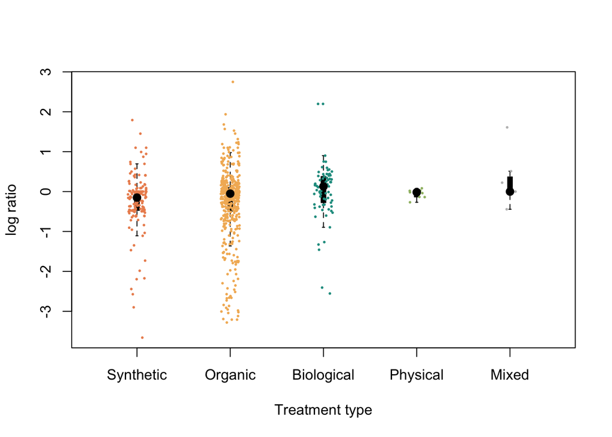

```r
plot(All_bees_data$logratio ~ All_bees_data$chem_split,
     col ="black",
     bty = "n",
     boxwex = 0.05,
     ylab = "log ratio",
     xlab = "Treatment type",
     pch = 16,
     cex = 0,
     names = c("Synthetic", "Organic", "Biological", "Physical", "Mixed"))

#We can plot the points for Synthetic
points(All_bees_data[All_bees_data$chem_split == "Synthetic", "logratio"] ~ jitter(as.integer(All_bees_data[All_bees_data$chem_split == "Synthetic",                                           "chem_split"]),
                  amount = 0.1),
       pch = 16,
       col = rgb(236, 143, 94, max=255),
       cex = 0.4)

points(median(All_bees_data[All_bees_data$chem_split == "Synthetic", "logratio"])
       ~ c(1),
       pch = 16,
       col = "black",
       cex = 1.3)


#We can plot the points for Agriculturally_Organic
points(All_bees_data[All_bees_data$chem_split == "Agriculturally_Organic", "logratio"] ~ jitter(as.integer(All_bees_data[All_bees_data$chem_split == "Agriculturally_Organic",                                           "chem_split"]),
                  amount = 0.1),
       pch = 16,
       col = rgb(243, 182, 100, max=255),
       cex = 0.4)


points(median(All_bees_data[All_bees_data$chem_split == "Agriculturally_Organic",
                            "logratio"])
       ~ c(2),
       pch = 16,
       col = "black",
       cex = 1.3)



#We can plot the points for Biological
points(All_bees_data[All_bees_data$chem_split == "Biological", "logratio"] ~ jitter(as.integer(All_bees_data[All_bees_data$chem_split == "Biological",                                           "chem_split"]),
                  amount = 0.1),
       pch = 16,
       col = rgb(33, 156, 144, max=255),
       cex = 0.4)

points(median(All_bees_data[All_bees_data$chem_split == "Biological",
                            "logratio"])
       ~ c(3),
       pch = 16,
       col = "black",
       cex = 1.3)



#We can plot the points for Physical
points(All_bees_data[All_bees_data$chem_split == "Physical", "logratio"] ~ jitter(as.integer(All_bees_data[All_bees_data$chem_split == "Physical",                                           "chem_split"]),
                  amount = 0.1),
       pch = 16,
       col = rgb(159, 187, 115, max=255),
       cex = 0.4)


points(median(All_bees_data[All_bees_data$chem_split == "Physical",
                            "logratio"])
       ~ c(4),
       pch = 16,
       col = "black",
       cex = 1.3)



#We can plot the points for Mixed
points(All_bees_data[All_bees_data$chem_split == "Mixed", "logratio"] ~ jitter(as.integer(All_bees_data[All_bees_data$chem_split == "Mixed",
                                                     "chem_split"]),
                                                      amount = 0.1),
                                                      pch = 16,
                                                      col = "grey",
                                                      cex = 0.4)

points(median(All_bees_data[All_bees_data$chem_split == "Mixed",
                            "logratio"])
       ~ c(5),
       pch = 16,
       col = "black",
       cex = 1.3)
```

# Main model with effects just on Varrora

We can also do the main model with just Varroa data included. Here we include both studies that measure increases or decreases in Varroa population or health data. Again the log ratio is calculated so that a positive value indicates a positive outcome for bee health/populations (that is a reduction in Varroa is indicated in positive terms.).

```r
All_varroa_data <- rbind(VarroaReduction_paired_fin,
                       VarroaIncrease_paired_red_fin)

All_varroa_data_mod <- MCMCglmm(logratio ~ chem_split
                                + Context,
                                 rcov=~units,
                                 random =~StudyID_control
                                          + Continent
                                          + Cont_Country,
                                 family ="gaussian",
                                 data = All_varroa_data,
                                 nitt = nitt,
                                 thin = thining,
                                 burnin = burnin,
                                 prior = prior_d,
                                 verbose = FALSE
                            )


All_varroa_data_mod2 <- MCMCglmm(logratio ~ chem_split
                                 + Context,
                                 rcov=~units,
                                 random =~StudyID_control
                                          + Continent
                                          + Cont_Country,
                                 family ="gaussian",
                                 data = All_varroa_data,
                                 nitt = nitt,
                                 thin = thining,
                                 burnin = burnin,
                                 prior = prior_d,
                                 verbose = FALSE
                            )

All_varroa_data_mod3 <- MCMCglmm(logratio ~ chem_split
                                 + Context,
                                 rcov=~units,
                                 random =~StudyID_control
                                          + Continent
                                          + Cont_Country,
                                 family ="gaussian",
                                 data = All_varroa_data,
                                 nitt = nitt,
                                 thin = thining,
                                 burnin = burnin,
                                 prior = prior_d,
                                 verbose = FALSE
                            )


#Check the fixed terms
All_varroa_data_mod_Sol_conv <- gelman.diag(mcmc.list(All_varroa_data_mod$Sol,
                                               All_varroa_data_mod2$Sol,
                                               All_varroa_data_mod3$Sol))
All_varroa_data_mod_Sol_conv
```

```
## Potential scale reduction factors:
##
##                                  Point est. Upper C.I.
## (Intercept)                               1          1
## chem_splitAgriculturally_Organic          1          1
## chem_splitBiological                      1          1
## chem_splitPhysical                        1          1
## chem_splitMixed                           1          1
## ContextLab                                1          1
##
## Multivariate psrf
##
## 1
```

```r
#Check the random terms
All_varroa_data_mod_VCV_conv <- gelman.diag(mcmc.list(All_varroa_data_mod$VCV,
                                               All_varroa_data_mod2$VCV,
                                               All_varroa_data_mod3$VCV))
All_varroa_data_mod_VCV_conv
```

```
## Potential scale reduction factors:
##
##                 Point est. Upper C.I.
## StudyID_control       1.00       1.01
## Continent             1.04       1.04
## Cont_Country          1.00       1.00
## units                 1.00       1.00
##
## Multivariate psrf
##
## 1
```

```r
summary(All_varroa_data_mod)
```

```
##
##  Iterations = 10001:109951
##  Thinning interval  = 50
##  Sample size  = 2000
##
##  DIC: 3342.772
##
##  G-structure:  ~StudyID_control
##
##                 post.mean l-95% CI u-95% CI eff.samp
## StudyID_control    0.7392   0.5296   0.9619     2000
##
##                ~Continent
##
##           post.mean l-95% CI u-95% CI eff.samp
## Continent   0.09946 5.22e-10   0.4065     1663
##
##                ~Cont_Country
##
##              post.mean  l-95% CI u-95% CI eff.samp
## Cont_Country   0.05027 1.946e-08   0.1908     1217
##
##  R-structure:  ~units
##
##       post.mean l-95% CI u-95% CI eff.samp
## units    0.6342   0.5854   0.6828     2133
##
##  Location effects: logratio ~ chem_split + Context
##
##                                  post.mean l-95% CI u-95% CI eff.samp  pMCMC
## (Intercept)                        1.60030  1.26960  1.98788     2000 <5e-04
## chem_splitAgriculturally_Organic  -0.14781 -0.32413  0.01634     2130  0.083
## chem_splitBiological              -1.03388 -1.32984 -0.70805     2000 <5e-04
## chem_splitPhysical                -0.83448 -1.50641 -0.10420     2000  0.015
## chem_splitMixed                   -0.77213 -1.63028  0.25965     2000  0.121
## ContextLab                        -0.15904 -0.43527  0.09414     2000  0.250
##
## (Intercept)                      ***
## chem_splitAgriculturally_Organic .
## chem_splitBiological             ***
## chem_splitPhysical               *
## chem_splitMixed
## ContextLab
## ---
## Signif. codes:  0 '***' 0.001 '**' 0.01 '*' 0.05 '.' 0.1 ' ' 1
```

We can do a simple plot of our results.

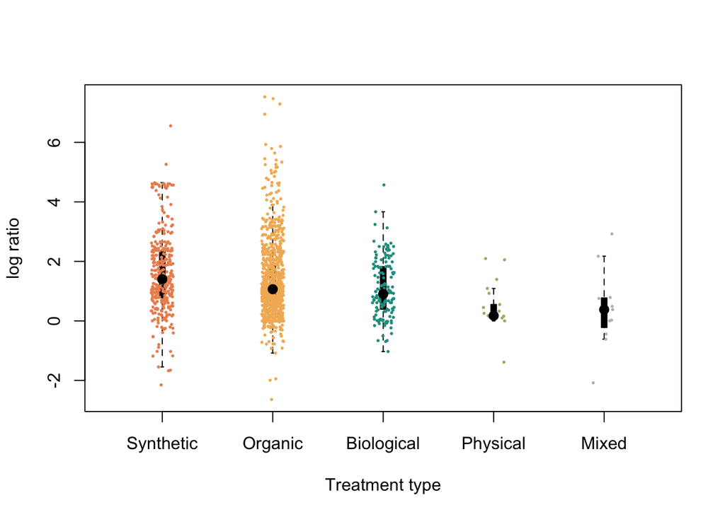

```r
plot(All_varroa_data$logratio ~ All_varroa_data$chem_split,
     col ="black",
     bty = "n",
     boxwex = 0.05,
     ylab = "log ratio",
     xlab = "Treatment type",
     pch = 16,
     cex = 0,
    names = c("Synthetic", "Organic", "Biological", "Physical", "Mixed"))

#We can plot the points for Synthetic
points(All_varroa_data[All_varroa_data$chem_split == "Synthetic", "logratio"] ~ jitter(as.integer(All_varroa_data[All_varroa_data$chem_split == "Synthetic",                                           "chem_split"]),
                  amount = 0.1),
       pch = 16,
       col = rgb(236, 143, 94, max=255),
       cex = 0.4)

points(median(All_varroa_data[All_varroa_data$chem_split == "Synthetic",
                            "logratio"])
       ~ c(1),
       pch = 16,
       col = "black",
       cex = 1.3)


#We can plot the points for Agriculturally_Organic
points(All_varroa_data[All_varroa_data$chem_split == "Agriculturally_Organic",
                       "logratio"]
       ~ jitter(as.integer(All_varroa_data[All_varroa_data$chem_split ==
                                             "Agriculturally_Organic",
                                           "chem_split"]),
                                            amount = 0.1),
                                            pch = 16,
                                            col = rgb(243, 182, 100, max=255),
                                            cex = 0.4)

points(median(All_varroa_data[All_varroa_data$chem_split == "Agriculturally_Organic",
                            "logratio"])
       ~ c(2),
       pch = 16,
       col = "black",
       cex = 1.3)



#We can plot the points for Biological
points(All_varroa_data[All_varroa_data$chem_split == "Biological", "logratio"] ~ jitter(as.integer(All_varroa_data[All_varroa_data$chem_split == "Biological",                                           "chem_split"]),
                  amount = 0.1),
       pch = 16,
       col = rgb(33, 156, 144, max=255),
       cex = 0.4)

points(median(All_varroa_data[All_varroa_data$chem_split == "Biological",
                            "logratio"])
       ~ c(3),
       pch = 16,
       col = "black",
       cex = 1.3)


#We can plot the points for Physical
points(All_varroa_data[All_varroa_data$chem_split == "Physical", "logratio"] ~ jitter(as.integer(All_varroa_data[All_varroa_data$chem_split == "Physical",                                           "chem_split"]),
                  amount = 0.1),
       pch = 16,
       col = rgb(159, 187, 115, max=255),
       cex = 0.4)

points(median(All_varroa_data[All_varroa_data$chem_split == "Physical",
                            "logratio"])
       ~ c(4),
       pch = 16,
       col = "black",
       cex = 1.3)



#We can plot the points for Mixed
points(All_varroa_data[All_varroa_data$chem_split == "Mixed", "logratio"] ~ jitter(as.integer(All_varroa_data[All_varroa_data$chem_split == "Mixed",
                                                     "chem_split"]),
                                                      amount = 0.1),
                                                      pch = 16,
                                                      col = "grey",
                                                      cex = 0.4)

points(median(All_varroa_data[All_varroa_data$chem_split == "Mixed",
                            "logratio"])
       ~ c(5),
       pch = 16,
       col = "black",
       cex = 1.3)
```

# Chemical treatment sub analysis

# break down each of the chemicals

We can compare each of the specific chemicals for which we had enough data.

```r
temp_Sub_chem <- Full_comb_data

#combine Flumethrin and Fluvalinate and call them Pyrethroid
temp_Sub_chem[temp_Sub_chem$broadTreatment %in% c("Flumethrin",
                                                  "Fluvalinate"),
              "broadTreatment"] <- "Pyrethroid"

Sub_chem <- temp_Sub_chem[temp_Sub_chem$broadTreatment %in%
c("Amitraz",
  "Coumaphos",
  "Thymol",
  "Oxalic_acid",
  "Formic_acid",
  "Pyrethroid"), ]

Sub_chem$broadTreatment <- factor(Sub_chem$broadTreatment)
```

We can now run the model comparing each of the size chemical groups to a baseline. We use Amitraz as the baseline here as its got a large sample size and as its one of the most effective trreatments making the contrasts a little easier to interpreate.

```r
mod_spec_chem <- MCMCglmm(logratio ~ broadTreatment + Context,
                                 rcov=~units,
                                 random =~StudyID
                                          + Continent
                                          + Cont_Country,
                                 family ="gaussian",
                                 data = Sub_chem,
                                 nitt = nitt,
                                 thin = thining,
                                 burnin = burnin,
                                 prior = prior_d,
                                 verbose = FALSE
                            )

mod_spec_chem2 <- MCMCglmm(logratio ~ broadTreatment + Context,
                                 rcov=~units,
                                 random =~StudyID
                                          + Continent
                                          + Cont_Country,
                                 family ="gaussian",
                                 data = Sub_chem,
                                 nitt = nitt,
                                 thin = thining,
                                 burnin = burnin,
                                 prior = prior_d,
                                 verbose = FALSE
                            )


mod_spec_chem3 <- MCMCglmm(logratio ~ broadTreatment + Context,
                                 rcov=~units,
                                 random =~StudyID
                                          + Continent
                                          + Cont_Country,
                                 family ="gaussian",
                                 data = Sub_chem,
                                 nitt = nitt,
                                 thin = thining,
                                 burnin = burnin,
                                 prior = prior_d,
                                 verbose = FALSE
                            )



#Check the fixed terms
mod_spec_chem_Sol_conv <- gelman.diag(mcmc.list(mod_spec_chem$Sol,
                                               mod_spec_chem2$Sol,
                                               mod_spec_chem3$Sol))
mod_spec_chem_Sol_conv
```

```
## Potential scale reduction factors:
##
##                           Point est. Upper C.I.
## (Intercept)                        1          1
## broadTreatmentCoumaphos            1          1
## broadTreatmentFormic_acid          1          1
## broadTreatmentOxalic_acid          1          1
## broadTreatmentPyrethroid           1          1
## broadTreatmentThymol               1          1
## ContextLab                         1          1
##
## Multivariate psrf
##
## 1
```

```r
#Check the random terms
mod_spec_chem_VCV_conv <- gelman.diag(mcmc.list(mod_spec_chem$VCV,
                                               mod_spec_chem2$VCV,
                                               mod_spec_chem3$VCV))
mod_spec_chem_VCV_conv
```

```
## Potential scale reduction factors:
##
##              Point est. Upper C.I.
## StudyID            1.00       1.00
## Continent          1.14       1.15
## Cont_Country       1.00       1.01
## units              1.00       1.01
##
## Multivariate psrf
##
## 1
```

```r
summary(mod_spec_chem)
```

```
##
##  Iterations = 10001:109951
##  Thinning interval  = 50
##  Sample size  = 2000
##
##  DIC: 2793.725
##
##  G-structure:  ~StudyID
##
##         post.mean l-95% CI u-95% CI eff.samp
## StudyID    0.6113   0.3575   0.8967     2000
##
##                ~Continent
##
##           post.mean  l-95% CI u-95% CI eff.samp
## Continent    0.5245 9.246e-07    2.061     2000
##
##                ~Cont_Country
##
##              post.mean  l-95% CI u-95% CI eff.samp
## Cont_Country    0.1326 2.385e-07   0.4132     1596
##
##  R-structure:  ~units
##
##       post.mean l-95% CI u-95% CI eff.samp
## units     1.097   0.9936    1.203     2000
##
##  Location effects: logratio ~ broadTreatment + Context
##
##                           post.mean  l-95% CI  u-95% CI eff.samp pMCMC
## (Intercept)                1.191101  0.435342  1.910390     2000 0.008 **
## broadTreatmentCoumaphos   -0.508754 -0.883824 -0.104647     1831 0.013 *
## broadTreatmentFormic_acid -0.256939 -0.564482  0.072959     2178 0.109
## broadTreatmentOxalic_acid -0.153716 -0.546429  0.246039     2000 0.438
## broadTreatmentPyrethroid   0.001078 -0.282089  0.297141     2000 0.991
## broadTreatmentThymol      -0.105655 -0.410113  0.173318     2156 0.469
## ContextLab                 0.006036 -0.526165  0.583873     2000 0.961
## ---
## Signif. codes:  0 '***' 0.001 '**' 0.01 '*' 0.05 '.' 0.1 ' ' 1
```

Coumaphos is significantly less effective compared to Amitraz at a ratio of 0.6/1 with all other chemicals not different.

We can do a simple plot of our results.

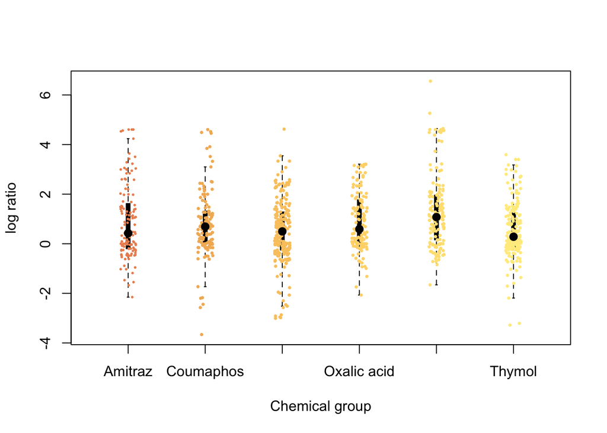

```r
plot(Sub_chem$logratio ~ Sub_chem$broadTreatment,
     col ="black",
     bty = "n",
     boxwex = 0.05,
     ylab = "log ratio",
     xlab = "Chemical group",
     pch = 16,
     cex = 0,
     names = c("Amitraz",
               "Coumaphos",
               "Formic acid",
               "Oxalic acid",
               "Pyrethroid",
               "Thymol"))

#We can plot the points for Amitraz
points(Sub_chem[Sub_chem$broadTreatment == "Amitraz", "logratio"] ~
         jitter(as.integer(Sub_chem[Sub_chem$broadTreatment == "Amitraz",
                                    "broadTreatment"]),
                  amount = 0.1),
       pch = 16,
       col = rgb(236, 143, 94, max=255),
       cex = 0.4)

points(median(Sub_chem[Sub_chem$broadTreatment == "Amitraz", "logratio"])
       ~ c(1),
       pch = 16,
       col = "black",
       cex = 1.3)



#We can plot the points for Coumaphos
points(Sub_chem[Sub_chem$broadTreatment == "Coumaphos", "logratio"] ~
         jitter(as.integer(Sub_chem[Sub_chem$broadTreatment == "Coumaphos",
                                    "broadTreatment"]),amount = 0.1),
       pch = 16,col = rgb(243, 182, 100, max=255),
       cex = 0.5)

points(median(Sub_chem[Sub_chem$broadTreatment == "Coumaphos", "logratio"])
       ~ c(2),
       pch = 16,
       col = "black",
       cex = 1.3)



#We can plot the points for Formic_acid
points(Sub_chem[Sub_chem$broadTreatment == "Formic_acid", "logratio"] ~
         jitter(as.integer(Sub_chem[Sub_chem$broadTreatment == "Formic_acid",
                                    "broadTreatment"]),amount = 0.1),
       pch = 16,
       col = rgb(250, 200, 110, max=255),
       cex = 0.5)

points(median(Sub_chem[Sub_chem$broadTreatment == "Formic_acid", "logratio"])
       ~ c(3),
       pch = 16,
       col = "black",
       cex = 1.3)


#We can plot the points for Oxalic_acid
points(Sub_chem[Sub_chem$broadTreatment == "Oxalic_acid", "logratio"] ~
         jitter(as.integer(Sub_chem[Sub_chem$broadTreatment == "Oxalic_acid",
                                    "broadTreatment"]),
                  amount = 0.1),
       pch = 16,
       col = rgb(255, 215, 120, max=255),
       cex = 0.5)

points(median(Sub_chem[Sub_chem$broadTreatment == "Oxalic_acid", "logratio"])
       ~ c(4),
       pch = 16,
       col = "black",
       cex = 1.3)



#We can plot the points for Pyrethroid
points(Sub_chem[Sub_chem$broadTreatment == "Pyrethroid", "logratio"] ~
         jitter(as.integer(Sub_chem[Sub_chem$broadTreatment == "Pyrethroid",
                                    "broadTreatment"]),
                  amount = 0.1),
       pch = 16,
       col = rgb(255, 225, 130, max=255),
       cex = 0.5)

points(median(Sub_chem[Sub_chem$broadTreatment == "Pyrethroid", "logratio"])
       ~ c(5),
       pch = 16,
       col = "black",
       cex = 1.3)


#We can plot the points for Thymol
points(Sub_chem[Sub_chem$broadTreatment == "Thymol", "logratio"] ~
         jitter(as.integer(Sub_chem[Sub_chem$broadTreatment == "Thymol",
                                    "broadTreatment"]),
                  amount = 0.1),
       pch = 16,
       col = rgb(255, 235, 140, max=255),
       cex = 0.5)

points(median(Sub_chem[Sub_chem$broadTreatment == "Thymol", "logratio"])
       ~ c(6),
       pch = 16,
       col = "black",
       cex = 1.3)
```

# Biological

Lets look at the Biological sub category

```r
Full_bio <-  Full_comb_data[Full_comb_data$categoryTreatment == "Biological",]

Full_bio$SubCategory1Treatment <- factor(Full_bio$SubCategory1Treatment)

nitt_b <- 2200000
thining_b <- 1000
burnin_b <- 200000

 mod_Full_bio <- MCMCglmm(logratio ~ SubCategory1Treatment + Context,
                                 rcov=~units,
                                 random =~StudyID_control
                                          + Continent
                                          + Cont_Country,
                                 family ="gaussian",
                                 data = Full_bio,
                                 nitt = nitt_b,
                                 thin = thining_b,
                                 burnin = burnin_b,
                                 verbose = FALSE
                            )


mod_Full_bio2 <- MCMCglmm(logratio ~ SubCategory1Treatment + Context,
                                 rcov=~units,
                                 random =~StudyID_control
                                          + Continent
                                          + Cont_Country,
                                 family ="gaussian",
                                 data = Full_bio,
                                 nitt = nitt_b,
                                 thin = thining_b,
                                 burnin = burnin_b,
                                 verbose = FALSE
                            )


mod_Full_bio3 <- MCMCglmm(logratio ~ SubCategory1Treatment + Context,
                                 rcov=~units,
                                 random =~StudyID_control
                                          + Continent
                                          + Cont_Country,
                                 family ="gaussian",
                                 data = Full_bio,
                                 nitt = nitt_b,
                                 thin = thining_b,
                                 burnin = burnin_b,
                                 verbose = FALSE
                            )

#Check the fixed terms
mod_Full_bio_Sol_conv <- gelman.diag(mcmc.list(mod_Full_bio$Sol,
                                               mod_Full_bio2$Sol,
                                               mod_Full_bio3$Sol))
mod_Full_bio_Sol_conv
```

```
## Potential scale reduction factors:
##
##                                      Point est. Upper C.I.
## (Intercept)                                   1          1
## SubCategory1TreatmentNatural_enemies          1          1
## ContextLab                                    1          1
##
## Multivariate psrf
##
## 1
```

```r
#Check the random terms
mod_Full_bio_VCV_conv <- gelman.diag(mcmc.list(mod_Full_bio$VCV,
                                               mod_Full_bio2$VCV,
                                               mod_Full_bio3$VCV))
mod_Full_bio_VCV_conv
```

```
## Potential scale reduction factors:
##
##                 Point est. Upper C.I.
## StudyID_control       1.01       1.01
## Continent             1.23       1.23
## Cont_Country          1.05       1.06
## units                 1.00       1.01
##
## Multivariate psrf
##
## 1
```

```r
summary(mod_Full_bio)
```

```
##
##  Iterations = 200001:2199001
##  Thinning interval  = 1000
##  Sample size  = 2000
##
##  DIC: 635.0454
##
##  G-structure:  ~StudyID_control
##
##                 post.mean  l-95% CI u-95% CI eff.samp
## StudyID_control    0.1049 1.493e-16   0.3069     1495
##
##                ~Continent
##
##           post.mean  l-95% CI u-95% CI eff.samp
## Continent   0.01673 3.018e-17  0.02666     1297
##
##                ~Cont_Country
##
##              post.mean  l-95% CI u-95% CI eff.samp
## Cont_Country  0.006574 5.508e-17  0.03013     1032
##
##  R-structure:  ~units
##
##       post.mean l-95% CI u-95% CI eff.samp
## units    0.9776   0.7949    1.175     1904
##
##  Location effects: logratio ~ SubCategory1Treatment + Context
##
##                                      post.mean l-95% CI u-95% CI eff.samp pMCMC
## (Intercept)                            0.70047  0.20788  1.18192     2000 0.007
## SubCategory1TreatmentNatural_enemies  -0.10206 -0.70700  0.46027     2000 0.736
## ContextLab                             0.05062 -0.56316  0.51348     2000 0.797
##
## (Intercept)                          **
## SubCategory1TreatmentNatural_enemies
## ContextLab
## ---
## Signif. codes:  0 '***' 0.001 '**' 0.01 '*' 0.05 '.' 0.1 ' ' 1
```

Here bee bread has a significant effect compared to the null of about 2/1 with no significant difference of the effect of Natural enemies.

We can do a simple plot of our results.

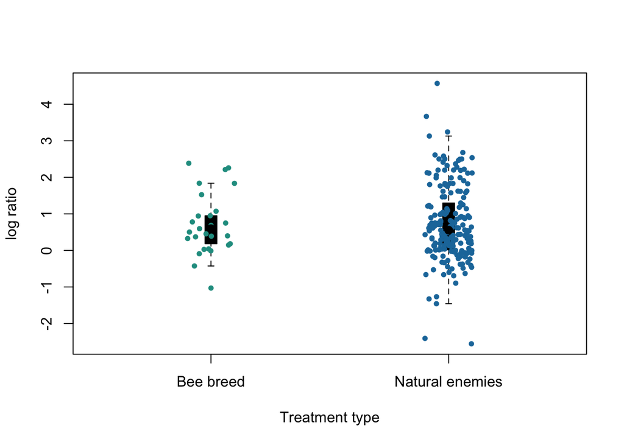

```r
plot(Full_bio$logratio ~ Full_bio$SubCategory1Treatment,
     col ="black",
     bty = "n",
     boxwex = 0.05,
     ylab = "log ratio",
     xlab = "Treatment type",
     pch = 16,
     cex = 0,
     names = c("Bee breed", "Natural enemies"))


#We can plot the points for Bee_breed
points(Full_bio[Full_bio$SubCategory1Treatment == "Bee_breed", "logratio"] ~
         jitter(as.integer(Full_bio[Full_bio$SubCategory1Treatment == "Bee_breed",                                           "SubCategory1Treatment"]),
                  amount = 0.1),
       pch = 16,
       col = rgb(33, 156, 144, max=255),
       cex = 0.8)

points(median(Full_bio[Full_bio$SubCategory1Treatment == "Bee_breed", "logratio"])
       ~ c(1),
       pch = 16,
       col = "black",
       cex = 1.3)


#We can plot the points for Natural_enemies
points(Full_bio[Full_bio$SubCategory1Treatment == "Natural_enemies", "logratio"] ~
         jitter(as.integer(Full_bio[Full_bio$SubCategory1Treatment == "Natural_enemies",                                           "SubCategory1Treatment"]),
                  amount = 0.1),
       pch = 16,
       col = rgb(30, 120, 170, max=255),
       cex = 0.8)


points(median(Full_bio[Full_bio$SubCategory1Treatment == "Natural_enemies",
                       "logratio"]) ~ c(2),
       pch = 16,
       col = "black",
       cex = 1.3)
```

# Life stage

## Models of life stage target

We will look at life stage separately for bees and Varroa.

## Bees life stage

First lets do it for bees. We will create 6 groups Synthetic chemical treatment on Honey bee worker, Synthetic chemical treatment on juvenile, Organic chemical treatment on Honey bee worker, Organic chemical treatment on juvenile, Biological treatment on Honey bee worker and Biological treatment on juveniles.

```r
life_bees_data <- Full_bees_data[Full_bees_data$ResponseVariableTarget %in%
                                   c("Honey_bee_worker",
                                     "Honey_bee_juvenile"),]

life_bees_data <- life_bees_data[life_bees_data$chem_split %in%
                                   c("Agriculturally_Organic",
                                     "Synthetic",
                                     "Biological"),]

life_bees_data$life_treat <- paste(life_bees_data$chem_split,
                                 life_bees_data$ResponseVariableTarget,
                                 sep = "_")

life_bees_data$life_treat <- factor(life_bees_data$life_treat,
                                    levels = c("Synthetic_Honey_bee_worker",
                                               "Synthetic_Honey_bee_juvenile",
                                               "Agriculturally_Organic_Honey_bee_worker",
                                               "Agriculturally_Organic_Honey_bee_juvenile",
                                               "Biological_Honey_bee_worker",
                                               "Biological_Honey_bee_juvenile"))

mod_bees_life <- MCMCglmm(logratio ~ life_treat + Context,
                                 rcov=~units,
                                 random =~StudyID_control
                                          + Continent
                                          + Cont_Country,
                                 family ="gaussian",
                                 data = life_bees_data,
                                 nitt = nitt,
                                 thin = thining,
                                 burnin = burnin,
                                 prior = prior_d,
                                 verbose = FALSE
                            )


mod_bees_life2 <- MCMCglmm(logratio ~ life_treat + Context,
                                 rcov=~units,
                                 random =~StudyID_control
                                          + Continent
                                          + Cont_Country,
                                 family ="gaussian",
                                 data = life_bees_data,
                                 nitt = nitt,
                                 thin = thining,
                                 burnin = burnin,
                                 prior = prior_d,
                                 verbose = FALSE
                            )

mod_bees_life3 <- MCMCglmm(logratio ~ life_treat + Context,
                                 rcov=~units,
                                 random =~StudyID_control
                                          + Continent
                                          + Cont_Country,
                                 family ="gaussian",
                                 data = life_bees_data,
                                 nitt = nitt,
                                 thin = thining,
                                 burnin = burnin,
                                 prior = prior_d,
                                 verbose = FALSE
                            )


#Check the fixed terms
mod_bees_life_Sol_conv <- gelman.diag(mcmc.list(mod_bees_life$Sol,
                                               mod_bees_life2$Sol,
                                               mod_bees_life3$Sol))
mod_bees_life_Sol_conv
```

```
## Potential scale reduction factors:
##
##                                                     Point est. Upper C.I.
## (Intercept)                                                  1       1.01
## life_treatSynthetic_Honey_bee_juvenile                       1       1.01
## life_treatAgriculturally_Organic_Honey_bee_worker            1       1.01
## life_treatAgriculturally_Organic_Honey_bee_juvenile          1       1.01
## life_treatBiological_Honey_bee_worker                        1       1.00
## life_treatBiological_Honey_bee_juvenile                      1       1.00
## ContextLab                                                   1       1.01
##
## Multivariate psrf
##
## 1
```

```r
#Check the random terms
mod_bees_life_VCV_conv <- gelman.diag(mcmc.list(mod_bees_life$VCV,
                                               mod_bees_life2$VCV,
                                               mod_bees_life3$VCV))
mod_bees_life_VCV_conv
```

```
## Potential scale reduction factors:
##
##                 Point est. Upper C.I.
## StudyID_control       1.00       1.00
## Continent             1.01       1.02
## Cont_Country          1.01       1.01
## units                 1.00       1.00
##
## Multivariate psrf
##
## 1
```

```r
summary(mod_bees_life)
```

```
##
##  Iterations = 10001:109951
##  Thinning interval  = 50
##  Sample size  = 2000
##
##  DIC: 1153.194
##
##  G-structure:  ~StudyID_control
##
##                 post.mean l-95% CI u-95% CI eff.samp
## StudyID_control    0.3406   0.1929   0.5067     2000
##
##                ~Continent
##
##           post.mean  l-95% CI u-95% CI eff.samp
## Continent   0.07865 7.005e-08   0.3011     2000
##
##                ~Cont_Country
##
##              post.mean  l-95% CI u-95% CI eff.samp
## Cont_Country   0.02481 4.991e-10  0.09104     1748
##
##  R-structure:  ~units
##
##       post.mean l-95% CI u-95% CI eff.samp
## units    0.3583   0.3195   0.4032     2000
##
##  Location effects: logratio ~ life_treat + Context
##
##                                                     post.mean l-95% CI u-95% CI
## (Intercept)                                          -0.41514 -0.76778 -0.06714
## life_treatSynthetic_Honey_bee_juvenile                0.34114 -0.07572  0.78276
## life_treatAgriculturally_Organic_Honey_bee_worker     0.14261 -0.04096  0.32367
## life_treatAgriculturally_Organic_Honey_bee_juvenile   0.21418 -0.04317  0.45515
## life_treatBiological_Honey_bee_worker                 0.31687 -0.08780  0.73535
## life_treatBiological_Honey_bee_juvenile               0.95521  0.49183  1.39507
## ContextLab                                           -0.23536 -0.55826  0.14373
##                                                     eff.samp  pMCMC
## (Intercept)                                             2000  0.037 *
## life_treatSynthetic_Honey_bee_juvenile                  2000  0.114
## life_treatAgriculturally_Organic_Honey_bee_worker       2000  0.141
## life_treatAgriculturally_Organic_Honey_bee_juvenile     2000  0.092 .
## life_treatBiological_Honey_bee_worker                   2000  0.128
## life_treatBiological_Honey_bee_juvenile                 2000 <5e-04 ***
## ContextLab                                              1840  0.200
## ---
## Signif. codes:  0 '***' 0.001 '**' 0.01 '*' 0.05 '.' 0.1 ' ' 1
```

We can do a simple plot of our results.

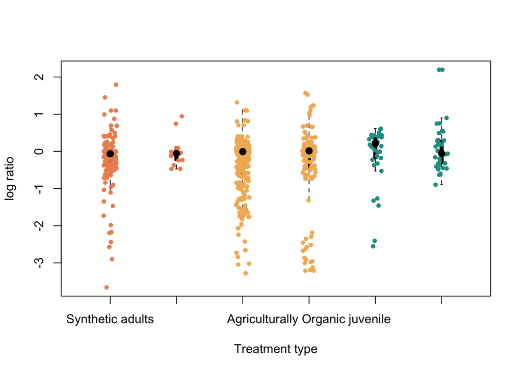

```r
plot(life_bees_data$logratio ~ life_bees_data$life_treat,
     col ="black",
     bty = "n",
     boxwex = 0.05,
     ylab = "log ratio",
     xlab = "Treatment type",
     pch = 16,
     cex = 0,
     names = c("Synthetic adults",
               "Synthetic juvenile",
               "Agriculturally Organic worker",
               "Agriculturally Organic juvenile",
               "Biological adults",
               "Biological juvenile"))


#We can plot the points for Synthetic_Honey_bee_worker
points(life_bees_data[life_bees_data$life_treat == "Synthetic_Honey_bee_worker", "logratio"] ~
         jitter(as.integer(life_bees_data[life_bees_data$life_treat == "Synthetic_Honey_bee_worker",                                           "life_treat"]),
                  amount = 0.1),
       pch = 16,
       col = rgb(236, 143, 94, max=255),
       cex = 0.8)

points(hdr(life_bees_data[life_bees_data$life_treat == "Synthetic_Honey_bee_worker",
                       "logratio"])$mode
       ~ c(1),
       pch = 16,
       col = "black",
       cex = 1.3)


#We can plot the points for Synthetic_Honey_bee_juvenile
points(life_bees_data[life_bees_data$life_treat == "Synthetic_Honey_bee_juvenile",
                      "logratio"] ~
         jitter(as.integer(life_bees_data[life_bees_data$life_treat == "Synthetic_Honey_bee_juvenile", "life_treat"]),
                  amount = 0.1),
       pch = 16,
       col = rgb(236, 143, 94, max=255),
       cex = 0.8)

points(hdr(life_bees_data[life_bees_data$life_treat == "Synthetic_Honey_bee_juvenile",
                       "logratio"])$mode
       ~ c(2),
       pch = 16,
       col = "black",
       cex = 1.3)



#We can plot the points for Agriculturally_Organic_Honey_bee_worker
points(life_bees_data[life_bees_data$life_treat == "Agriculturally_Organic_Honey_bee_worker",
                      "logratio"] ~
         jitter(as.integer(life_bees_data[life_bees_data$life_treat == "Agriculturally_Organic_Honey_bee_worker", "life_treat"]),
                  amount = 0.1),
       pch = 16,
       col = rgb(243, 182, 100, max=255),
       cex = 0.8)

points(hdr(life_bees_data[life_bees_data$life_treat == "Agriculturally_Organic_Honey_bee_worker",
                       "logratio"])$mode
       ~ c(3),
       pch = 16,
       col = "black",
       cex = 1.3)




#We can plot the points for Agriculturally_Organic_Honey_bee_juvenile
points(life_bees_data[life_bees_data$life_treat == "Agriculturally_Organic_Honey_bee_juvenile",
                      "logratio"] ~
         jitter(as.integer(life_bees_data[life_bees_data$life_treat == "Agriculturally_Organic_Honey_bee_juvenile", "life_treat"]),
                  amount = 0.1),
       pch = 16,
       col = rgb(243, 182, 100, max=255),
       cex = 0.8)

points(hdr(life_bees_data[life_bees_data$life_treat == "Agriculturally_Organic_Honey_bee_juvenile",
                       "logratio"])$mode
       ~ c(4),
       pch = 16,
       col = "black",
       cex = 1.3)




#We can plot the points for Biological_Honey_bee_worker
points(life_bees_data[life_bees_data$life_treat == "Biological_Honey_bee_worker",
                      "logratio"] ~
         jitter(as.integer(life_bees_data[life_bees_data$life_treat == "Biological_Honey_bee_worker", "life_treat"]),
                  amount = 0.1),
       pch = 16,
       col = rgb(33, 156, 144, max=255),
       cex = 0.8)

points(hdr(life_bees_data[life_bees_data$life_treat == "Biological_Honey_bee_worker",
                       "logratio"])$mode
       ~ c(5),
       pch = 16,
       col = "black",
       cex = 1.3)




#We can plot the points for Biological_Honey_bee_juvenile
points(life_bees_data[life_bees_data$life_treat == "Biological_Honey_bee_juvenile",
                      "logratio"] ~
         jitter(as.integer(life_bees_data[life_bees_data$life_treat == "Biological_Honey_bee_juvenile", "life_treat"]),
                  amount = 0.1),
       pch = 16,
       col = rgb(33, 156, 144, max=255),
       cex = 0.8)

points(hdr(life_bees_data[life_bees_data$life_treat == "Biological_Honey_bee_juvenile",
                       "logratio"])$mode
       ~ c(6),
       pch = 16,
       col = "black",
       cex = 1.3)
```

# Supplementary analaysis

We can also look at the main model when split into just studies measruing increases in bees, which is for 44 studies for this analysis

```r
mod_HoneyBeeIncrease <- MCMCglmm(logratio ~ chem_split + Context,
                                 rcov=~units,
                                 random =~StudyID_control
                                          + Continent
                                          + Cont_Country,
                                 family ="gaussian",
                                 data = HoneyBeeIncrease_paired_fin,
                                 nitt = nitt,
                                 thin = thining,
                                 burnin = burnin,
                                 prior = prior_d,
                                 verbose = FALSE
                            )

mod_HoneyBeeIncrease2 <- MCMCglmm(logratio ~ chem_split + Context,
                                 rcov=~units,
                                 random =~StudyID_control
                                          + Continent
                                          + Cont_Country,
                                 family ="gaussian",
                                 data = HoneyBeeIncrease_paired_fin,
                                 nitt = nitt,
                                 thin = thining,
                                 burnin = burnin,
                                 prior = prior_d,
                                 verbose = FALSE
                            )

mod_HoneyBeeIncrease3 <- MCMCglmm(logratio ~ chem_split + Context,
                                 rcov=~units,
                                 random =~StudyID_control
                                          + Continent
                                          + Cont_Country,
                                 family ="gaussian",
                                 data = HoneyBeeIncrease_paired_fin,
                                 nitt = nitt,
                                 thin = thining,
                                 burnin = burnin,
                                 prior = prior_d,
                                 verbose = FALSE
                            )

#Check the fixed terms
mod_HoneyBeeIncrease_Sol_conv <- gelman.diag(mcmc.list(mod_HoneyBeeIncrease$Sol,
                                       mod_HoneyBeeIncrease2$Sol,
                                       mod_HoneyBeeIncrease3$Sol))
mod_HoneyBeeIncrease_Sol_conv
```

```
## Potential scale reduction factors:
##
##                                  Point est. Upper C.I.
## (Intercept)                               1          1
## chem_splitAgriculturally_Organic          1          1
## chem_splitBiological                      1          1
## chem_splitPhysical                        1          1
## chem_splitMixed                           1          1
## ContextLab                                1          1
##
## Multivariate psrf
##
## 1
```

```r
#Check the random terms
mod_HoneyBeeIncrease_VCV_conv <- gelman.diag(mcmc.list(mod_HoneyBeeIncrease$VCV,
                                       mod_HoneyBeeIncrease2$VCV,
                                       mod_HoneyBeeIncrease3$VCV))
mod_HoneyBeeIncrease_VCV_conv
```

```
## Potential scale reduction factors:
##
##                 Point est. Upper C.I.
## StudyID_control       1.00       1.00
## Continent             1.08       1.08
## Cont_Country          1.01       1.02
## units                 1.00       1.00
##
## Multivariate psrf
##
## 1
```

```r
summary(mod_HoneyBeeIncrease)
```

```
##
##  Iterations = 10001:109951
##  Thinning interval  = 50
##  Sample size  = 2000
##
##  DIC: 438.8189
##
##  G-structure:  ~StudyID_control
##
##                 post.mean l-95% CI u-95% CI eff.samp
## StudyID_control   0.02444 0.002584  0.05211     2000
##
##                ~Continent
##
##           post.mean  l-95% CI u-95% CI eff.samp
## Continent    0.1358 1.041e-06   0.4771      997
##
##                ~Cont_Country
##
##              post.mean l-95% CI u-95% CI eff.samp
## Cont_Country   0.08998 0.002049   0.2066     2000
##
##  R-structure:  ~units
##
##       post.mean l-95% CI u-95% CI eff.samp
## units    0.1415   0.1213   0.1607     2000
##
##  Location effects: logratio ~ chem_split + Context
##
##                                  post.mean l-95% CI u-95% CI eff.samp  pMCMC
## (Intercept)                       -0.19089 -0.58052  0.16269     2217  0.231
## chem_splitAgriculturally_Organic   0.17003  0.06544  0.28174     2000  0.002
## chem_splitBiological               0.55546  0.33619  0.77345     2000 <5e-04
## chem_splitPhysical                 0.24816 -0.09079  0.57328     2000  0.156
## chem_splitMixed                   -0.07185 -0.80952  0.82767     2000  0.840
## ContextLab                         0.34577  0.02494  0.64280     2000  0.026
##
## (Intercept)
## chem_splitAgriculturally_Organic **
## chem_splitBiological             ***
## chem_splitPhysical
## chem_splitMixed
## ContextLab                       *
## ---
## Signif. codes:  0 '***' 0.001 '**' 0.01 '*' 0.05 '.' 0.1 ' ' 1
```

# Studies that measure a decrease bee pops

This is with the original data so a positive value here is something that decreases bee pops and health. There is 36 studies here.

```r
mod_HoneyBeeReduction <- MCMCglmm(logratio ~ chem_split + Context,
                                 rcov=~units,
                                 random =~StudyID_control
                                          + Continent
                                          + Cont_Country,
                                 family ="gaussian",
                                 data = HoneyBeeReduction_paired_fin,
                                 nitt = nitt,
                                 thin = thining,
                                 burnin = burnin,
                                 prior = prior_d,
                                 verbose = FALSE
                            )
mod_HoneyBeeReduction2 <- MCMCglmm(logratio ~ chem_split + Context,
                                 rcov=~units,
                                 random =~StudyID_control
                                          + Continent
                                          + Cont_Country,
                                 family ="gaussian",
                                 data = HoneyBeeReduction_paired_fin,
                                 nitt = nitt,
                                 thin = thining,
                                 burnin = burnin,
                                 prior = prior_d,
                                 verbose = FALSE
                            )
mod_HoneyBeeReduction3 <- MCMCglmm(logratio ~ chem_split + Context,
                                 rcov=~units,
                                 random =~StudyID_control
                                          + Continent
                                          + Cont_Country,
                                 family ="gaussian",
                                 data = HoneyBeeReduction_paired_fin,
                                 nitt = nitt,
                                 thin = thining,
                                 burnin = burnin,
                                 prior = prior_d,
                                 verbose = FALSE
                            )
#Check the fixed terms
mod_HoneyBeeReduction_Sol_conv<- gelman.diag(mcmc.list(mod_HoneyBeeReduction$Sol,
                                       mod_HoneyBeeReduction2$Sol,
                                       mod_HoneyBeeReduction3$Sol))
mod_HoneyBeeReduction_Sol_conv
```

```
## Potential scale reduction factors:
##
##                                  Point est. Upper C.I.
## (Intercept)                               1       1.01
## chem_splitAgriculturally_Organic          1       1.00
## chem_splitBiological                      1       1.01
## chem_splitMixed                           1       1.00
## ContextLab                                1       1.00
##
## Multivariate psrf
##
## 1
```

```r
#Check the random terms
mod_HoneyBeeReduction_VCV_conv <- gelman.diag(mcmc.list(mod_HoneyBeeReduction$VCV,
                                       mod_HoneyBeeReduction2$VCV,
                                       mod_HoneyBeeReduction3$VCV))
mod_HoneyBeeReduction_VCV_conv
```

```
## Potential scale reduction factors:
##
##                 Point est. Upper C.I.
## StudyID_control          1          1
## Continent                1          1
## Cont_Country             1          1
## units                    1          1
##
## Multivariate psrf
##
## 1
```

```r
summary(mod_HoneyBeeReduction)
```

```
##
##  Iterations = 10001:109951
##  Thinning interval  = 50
##  Sample size  = 2000
##
##  DIC: 649.986
##
##  G-structure:  ~StudyID_control
##
##                 post.mean l-95% CI u-95% CI eff.samp
## StudyID_control      0.54    0.256   0.9023     2000
##
##                ~Continent
##
##           post.mean  l-95% CI u-95% CI eff.samp
## Continent    0.1887 9.519e-09   0.8118     2000
##
##                ~Cont_Country
##
##              post.mean l-95% CI u-95% CI eff.samp
## Cont_Country   0.08992 1.74e-08   0.3519     2000
##
##  R-structure:  ~units
##
##       post.mean l-95% CI u-95% CI eff.samp
## units    0.6138   0.5023   0.7283     2000
##
##  Location effects: logratio ~ chem_split + Context
##
##                                  post.mean l-95% CI u-95% CI eff.samp pMCMC
## (Intercept)                        0.30548 -0.42513  1.00961     2171 0.388
## chem_splitAgriculturally_Organic   0.35409 -0.21911  0.90164     2000 0.214
## chem_splitBiological               0.08642 -0.79025  0.85566     2000 0.840
## chem_splitMixed                   -0.66255 -2.54369  0.87941     2000 0.440
## ContextLab                         0.10148 -0.38439  0.60088     2000 0.683
```

We find no significant effects, likely due to the low sample size.

# Studies that measure a decreases in varroa pops

Analysis just including measures of Varroa decreases.

```r
mod_VarroaReduction <- MCMCglmm(logratio ~ chem_split + Context,
                                 rcov=~units,
                                 random =~StudyID_control
                                          + Continent
                                          + Cont_Country,
                                 family ="gaussian",
                                 data = VarroaReduction_paired_fin,
                                 nitt = nitt,
                                 thin = thining,
                                 burnin = burnin,
                                 prior = prior_d,
                                 verbose = FALSE)


mod_VarroaReduction2 <- MCMCglmm(logratio ~ chem_split + Context,
                                 rcov=~units,
                                 random =~StudyID_control
                                          + Continent
                                          + Cont_Country,
                                 family ="gaussian",
                                 data = VarroaReduction_paired_fin,
                                 nitt = nitt,
                                 thin = thining,
                                 burnin = burnin,
                                 prior = prior_d,
                                 verbose = FALSE)

mod_VarroaReduction3 <- MCMCglmm(logratio ~ chem_split + Context,
                                 rcov=~units,
                                 random =~StudyID_control
                                          + Continent
                                          + Cont_Country,
                                 family ="gaussian",
                                 data = VarroaReduction_paired_fin,
                                 nitt = nitt,
                                 thin = thining,
                                 burnin = burnin,
                                 prior = prior_d,
                                 verbose = FALSE)

#Check the fixed terms
mod_VarroaReduction_Sol_conv<- gelman.diag(mcmc.list(mod_VarroaReduction$Sol,
                                       mod_VarroaReduction2$Sol,
                                       mod_VarroaReduction3$Sol))
mod_VarroaReduction_Sol_conv
```

```
## Potential scale reduction factors:
##
##                                  Point est. Upper C.I.
## (Intercept)                               1          1
## chem_splitAgriculturally_Organic          1          1
## chem_splitBiological                      1          1
## chem_splitPhysical                        1          1
## chem_splitMixed                           1          1
## ContextLab                                1          1
##
## Multivariate psrf
##
## 1
```

```r
#Check the random terms
mod_VarroaReduction_VCV_conv <- gelman.diag(mcmc.list(mod_VarroaReduction$VCV,
                                       mod_VarroaReduction2$VCV,
                                       mod_VarroaReduction3$VCV))
mod_VarroaReduction_VCV_conv
```

```
## Potential scale reduction factors:
##
##                 Point est. Upper C.I.
## StudyID_control       1.00       1.00
## Continent             1.05       1.06
## Cont_Country          1.00       1.00
## units                 1.00       1.00
##
## Multivariate psrf
##
## 1
```

```r
summary(mod_VarroaReduction)
```

```
##
##  Iterations = 10001:109951
##  Thinning interval  = 50
##  Sample size  = 2000
##
##  DIC: 2251.365
##
##  G-structure:  ~StudyID_control
##
##                 post.mean l-95% CI u-95% CI eff.samp
## StudyID_control    0.7063   0.4772   0.9495     2000
##
##                ~Continent
##
##           post.mean  l-95% CI u-95% CI eff.samp
## Continent    0.1058 6.171e-10   0.4151     1803
##
##                ~Cont_Country
##
##              post.mean  l-95% CI u-95% CI eff.samp
## Cont_Country   0.07366 5.025e-08   0.2523     1445
##
##  R-structure:  ~units
##
##       post.mean l-95% CI u-95% CI eff.samp
## units    0.5389   0.4888   0.5879     2000
##
##  Location effects: logratio ~ chem_split + Context
##
##                                  post.mean l-95% CI u-95% CI eff.samp pMCMC
## (Intercept)                        1.61882  1.19431  2.04321     2000 0.002 **
## chem_splitAgriculturally_Organic  -0.22490 -0.43137  0.01104     2000 0.048 *
## chem_splitBiological              -0.69837 -1.12136 -0.26118     2000 0.001 ***
## chem_splitPhysical                -0.91371 -2.00987  0.14025     2000 0.107
## chem_splitMixed                    0.42236 -1.19272  2.20870     2000 0.677
## ContextLab                        -0.04209 -0.31983  0.23504     2000 0.764
## ---
## Signif. codes:  0 '***' 0.001 '**' 0.01 '*' 0.05 '.' 0.1 ' ' 1
```

Chemical studies are found to reduce Varroa at a ratio of about 5 to 1 when compared to controls. Organic chemical are slightly less effective a reducing varrora with a ratio of 4 to 1 while biological data reduce Varroa at a ratio of 2.5 to 1.